# Project 2 - No Show Appointment Data Analysis

## Project: Medical Appointment No Shows

- Introduction
- Data Wrangling
- Exploratory Data Analysis
- Conclusions

## Introduction

The data set that has been selected by me is Medical Appointment No Shows. I selected this data as I would like to understand patient behaviour and what results in they showing up or not showing up for appointments. Dataset variables seems to be self explanatory and the variables are PatientId, AppointmentID, Gender, ScheduledDay, AppointmentDay, Age, Neighbourhood, Scholarship, Hipertension, Diabetes, Alcoholism, Handcap, SMS_received, No-show

## Questions I am trying to answer are:

- Does Gender has any impact on patient to be with status Show / No-Show?
- Does Age has any impact on patient to be with status Show / No-Show?
- Is there any Age difference along with Gender difference with the status of Show / NoShow?

### Import all necessary packages and functions.

```python
import pandas as pd
import numpy as np
import datetime

import matplotlib.pyplot as plt
import seaborn as sns
color = sns.color_palette()
%matplotlib inline

import plotly.offline as py
py.init_notebook_mode(connected=True)
import plotly.graph_objs as go
import plotly.tools as tls

import seaborn as sns
sns.set(style="white")
sns.set(style="whitegrid", color_codes=True)
```

## Data Wrangling

- Drop Duplicate rows
- Drop outliers from age
- Drop missing values
- Remane variables to make them self explanatory
- Feature Engineering

### Load your data and print out a few lines

```python
df = pd.read_csv('noshowappointments-kagglev2-may-2016.csv')
df.head()
```

|  | PatientId | AppointmentID | Gender | ScheduledDay | AppointmentDay | Age | Neighbourhood | Scholarship | Hipertension | Diabetes | Alcoholism | Handcap | SMS_received | No-show |
| --- | --- | --- | --- | --- | --- | --- | --- | --- | --- | --- | --- | --- | --- | --- |
| 0 | 2.987250e+13 | 5642903 | F | 2016-04-29T18:38:08Z | 2016-04-29T00:00:00Z | 62 | JARDIM DA PENHA | 0 | 1 | 0 | 0 | 0 | 0 | No |
| 1 | 5.589980e+14 | 5642503 | M | 2016-04-29T16:08:27Z | 2016-04-29T00:00:00Z | 56 | JARDIM DA PENHA | 0 | 0 | 0 | 0 | 0 | 0 | No |
| 2 | 4.262960e+12 | 5642549 | F | 2016-04-29T16:19:04Z | 2016-04-29T00:00:00Z | 62 | MATA DA PRAIA | 0 | 0 | 0 | 0 | 0 | 0 | No |
| 3 | 8.679510e+11 | 5642828 | F | 2016-04-29T17:29:31Z | 2016-04-29T00:00:00Z | 8 | PONTAL DE CAMBURI | 0 | 0 | 0 | 0 | 0 | 0 | No |
| 4 | 8.841190e+12 | 5642494 | F | 2016-04-29T16:07:23Z | 2016-04-29T00:00:00Z | 56 | JARDIM DA PENHA | 0 | 1 | 1 | 0 | 0 | 0 | No |

```python
print(df.shape)
df.drop_duplicates(inplace = True)
print(df.shape)
```

```
(110527, 14)
(110527, 14)
```

There are no duplicate values

### Understanding data structure

```python
df.columns
```

```
Index(['PatientId', 'AppointmentID', 'Gender', 'ScheduledDay',
       'AppointmentDay', 'Age', 'Neighbourhood', 'Scholarship', 'Hipertension',
       'Diabetes', 'Alcoholism', 'Handcap', 'SMS_received', 'No-show'],
      dtype='object')
```

```python
df.nunique()
```

```
PatientId          61744
AppointmentID     110527
Gender                 2
ScheduledDay      103549
AppointmentDay        27
Age                  104
Neighbourhood         81
Scholarship            2
Hipertension           2
Diabetes               2
Alcoholism             2
Handcap                5
SMS_received           2
No-show                2
dtype: int64
```

```python
# All Object variables
df.select_dtypes(include=['object']).columns
```

```
Index(['Gender', 'ScheduledDay', 'AppointmentDay', 'Neighbourhood', 'No-show'], dtype='object')
```

```python
# All Numeric variables
df.select_dtypes(exclude=['object']).columns
```

```
Index(['PatientId', 'AppointmentID', 'Age', 'Scholarship', 'Hipertension',
       'Diabetes', 'Alcoholism', 'Handcap', 'SMS_received'],
      dtype='object')
```

```python
df.info()
```

```
<class 'pandas.core.frame.DataFrame'>
Int64Index: 110527 entries, 0 to 110526
Data columns (total 14 columns):
 #   Column          Non-Null Count   Dtype
---  ------          --------------   -----
 0   PatientId       110527 non-null  float64
 1   AppointmentID   110527 non-null  int64
 2   Gender          110527 non-null  object
 3   ScheduledDay    110527 non-null  object
 4   AppointmentDay  110527 non-null  object
 5   Age             110527 non-null  int64
 6   Neighbourhood   110527 non-null  object
 7   Scholarship     110527 non-null  int64
 8   Hipertension    110527 non-null  int64
 9   Diabetes        110527 non-null  int64
 10  Alcoholism      110527 non-null  int64
 11  Handcap         110527 non-null  int64
 12  SMS_received    110527 non-null  int64
 13  No-show         110527 non-null  object
dtypes: float64(1), int64(8), object(5)
memory usage: 12.6+ MB
```

There are no missing values in the dataset

### Create the summary report

```python
df.describe()
```

|  | PatientId | AppointmentID | Age | Scholarship | Hipertension | Diabetes | Alcoholism | Handcap | SMS_received |
| --- | --- | --- | --- | --- | --- | --- | --- | --- | --- |
| count | 1.105270e+05 | 1.105270e+05 | 110527.000000 | 110527.000000 | 110527.000000 | 110527.000000 | 110527.000000 | 110527.000000 | 110527.000000 |
| mean | 1.474963e+14 | 5.675305e+06 | 37.088874 | 0.098266 | 0.197246 | 0.071865 | 0.030400 | 0.022248 | 0.321026 |
| std | 2.560949e+14 | 7.129575e+04 | 23.110205 | 0.297675 | 0.397921 | 0.258265 | 0.171686 | 0.161543 | 0.466873 |
| min | 3.920000e+04 | 5.030230e+06 | -1.000000 | 0.000000 | 0.000000 | 0.000000 | 0.000000 | 0.000000 | 0.000000 |
| 25% | 4.172615e+12 | 5.640286e+06 | 18.000000 | 0.000000 | 0.000000 | 0.000000 | 0.000000 | 0.000000 | 0.000000 |
| 50% | 3.173180e+13 | 5.680573e+06 | 37.000000 | 0.000000 | 0.000000 | 0.000000 | 0.000000 | 0.000000 | 0.000000 |
| 75% | 9.439170e+13 | 5.725524e+06 | 55.000000 | 0.000000 | 0.000000 | 0.000000 | 0.000000 | 0.000000 | 1.000000 |
| max | 9.999820e+14 | 5.790484e+06 | 115.000000 | 1.000000 | 1.000000 | 1.000000 | 1.000000 | 4.000000 | 1.000000 |

We see an anomaly in age with minimum value as negative age and maximum above 100

### Checking for unique records

```python
df.shape, df['PatientId'].nunique(), df.AppointmentID.nunique()
```

```
((110527, 14), 61744, 110527)
```

## Cleaning Data

```python
df.Age.unique()
```

```
array([ 62,  56,   8,  76,  23,  39,  21,  19,  30,  29,  22,  28,  54,
        15,  50,  40,  46,   4,  13,  65,  45,  51,  32,  12,  61,  38,
        79,  18,  63,  64,  85,  59,  55,  71,  49,  78,  31,  58,  27,
         6,   2,  11,   7,   0,   3,   1,  69,  68,  60,  67,  36,  10,
        35,  20,  26,  34,  33,  16,  42,   5,  47,  17,  41,  44,  37,
        24,  66,  77,  81,  70,  53,  75,  73,  52,  74,  43,  89,  57,
        14,   9,  48,  83,  72,  25,  80,  87,  88,  84,  82,  90,  94,
        86,  91,  98,  92,  96,  93,  95,  97, 102, 115, 100,  99,  -1],
      dtype=int64)
```

#### Dropping negative and higher than 100 age records, treating them as outliers

```python
df[(df['Age'] < 0 ) | (df['Age'] > 100)].count()
```

```
PatientId         8
AppointmentID     8
Gender            8
ScheduledDay      8
AppointmentDay    8
Age               8
Neighbourhood     8
Scholarship       8
Hipertension      8
Diabetes          8
Alcoholism        8
Handcap           8
SMS_received      8
No-show           8
dtype: int64
```

```python
df = df[(df['Age'] >= 0) & (df['Age'] < 100)]
df['senior_citizen'] = [1 if x>=60 else 0 for x in df['Age']]
```

#### Renaming some column names where there is a spelling error for easy access

```python
df.rename(columns = {'PatientId':'Patientid' , 'AppointmentID':'Appointmentid' , 'ScheduledDay': 'Scheduledday' , 'AppointmentDay' : 'Appointmentday' , 'Hipertension':'Hypertension' , 'Handcap':'Handicap' , 'No-show':'Noshow'} , inplace = True)
```

```python
df['Scheduledday'] = pd.to_datetime(df['Scheduledday'])
df['scheduled_day'] = df['Scheduledday'].dt.day
df['scheduled_weekday'] = df['Scheduledday'].dt.dayofweek
df['scheduled_week'] = df['Scheduledday'].dt.week
df['scheduled_month'] = df['Scheduledday'].dt.month
df['scheduled_day_name'] = df['Scheduledday'].dt.day_name()

df['Appointmentday'] = pd.to_datetime(df['Appointmentday'])
df['appointment_day'] = df['Appointmentday'].dt.day
df['appointment_weekday'] = df['Appointmentday'].dt.dayofweek
df['appointment_week'] = df['Appointmentday'].dt.week
df['appointment_month'] = df['Appointmentday'].dt.month
df['appointment_day_name'] = df['Appointmentday'].dt.day_name()

print(df.shape)
df.head()
```

```
(110515, 25)
```

|  | Patientid | Appointmentid | Gender | Scheduledday | Appointmentday | Age | Neighbourhood | Scholarship | Hypertension | Diabetes | ... | scheduled_day | scheduled_weekday | scheduled_week | scheduled_month | scheduled_day_name | appointment_day | appointment_weekday | appointment_week | appointment_month | appointment_day_name |
| --- | --- | --- | --- | --- | --- | --- | --- | --- | --- | --- | --- | --- | --- | --- | --- | --- | --- | --- | --- | --- | --- |
| 0 | 2.987250e+13 | 5642903 | F | 2016-04-29 18:38:08+00:00 | 2016-04-29 00:00:00+00:00 | 62 | JARDIM DA PENHA | 0 | 1 | 0 | ... | 29 | 4 | 17 | 4 | Friday | 29 | 4 | 17 | 4 | Friday |
| 1 | 5.589980e+14 | 5642503 | M | 2016-04-29 16:08:27+00:00 | 2016-04-29 00:00:00+00:00 | 56 | JARDIM DA PENHA | 0 | 0 | 0 | ... | 29 | 4 | 17 | 4 | Friday | 29 | 4 | 17 | 4 | Friday |
| 2 | 4.262960e+12 | 5642549 | F | 2016-04-29 16:19:04+00:00 | 2016-04-29 00:00:00+00:00 | 62 | MATA DA PRAIA | 0 | 0 | 0 | ... | 29 | 4 | 17 | 4 | Friday | 29 | 4 | 17 | 4 | Friday |
| 3 | 8.679510e+11 | 5642828 | F | 2016-04-29 17:29:31+00:00 | 2016-04-29 00:00:00+00:00 | 8 | PONTAL DE CAMBURI | 0 | 0 | 0 | ... | 29 | 4 | 17 | 4 | Friday | 29 | 4 | 17 | 4 | Friday |
| 4 | 8.841190e+12 | 5642494 | F | 2016-04-29 16:07:23+00:00 | 2016-04-29 00:00:00+00:00 | 56 | JARDIM DA PENHA | 0 | 1 | 1 | ... | 29 | 4 | 17 | 4 | Friday | 29 | 4 | 17 | 4 | Friday |

5 rows × 25 columns

#### Checking for Patients with multiple appointments and having no show multiple times, just for data exploration

```python
No_show = df[df['Noshow'] == "Yes"]
No_show = No_show.groupby(['Patientid'])['Appointmentid'].count().reset_index()
No_show.rename(columns = {'Appointmentid' : 'No_of_noshows'} , inplace = True)
print(No_show.No_of_noshows.value_counts())
```

```
1     14366
2      2441
3       519
4       164
5        59
6        33
7        13
8         9
11        4
10        4
9         3
18        1
15        1
14        1
12        1
13        1
16        1
Name: No_of_noshows, dtype: int64
```

```python
No_show = No_show[No_show.No_of_noshows >= 10]
print(No_show)
```

```
          Patientid  No_of_noshows
1690   4.768620e+11             11
2928   1.198160e+12             12
3062   1.421990e+12             18
3726   2.728420e+12             11
4667   4.629580e+12             10
5133   5.587790e+12             15
7189   9.715140e+12             11
11252  6.575140e+13             13
13129  9.338860e+13             10
13571  9.915270e+13             10
14285  2.491640e+14             11
15693  5.635140e+14             16
15773  5.811970e+14             14
16919  8.485850e+14             10
```

The above PatientIDs are most regular 'No-showers'

```python
Total_visit = df.groupby(['Patientid'])['Appointmentid'].count().reset_index()
Total_visit.rename(columns = {'Appointmentid' : 'No_of_visits'} , inplace = True)

No_show_visit = pd.merge(No_show , Total_visit , how = 'inner' , on = "Patientid")
No_show_visit['Percentage_no_show'] = No_show_visit['No_of_noshows'] / No_show_visit['No_of_visits']*100
No_show_visit.drop(['No_of_noshows' , 'No_of_visits'] , axis = 1)
```

|  | Patientid | Percentage_no_show |
| --- | --- | --- |
| 0 | 4.768620e+11 | 91.666667 |
| 1 | 1.198160e+12 | 50.000000 |
| 2 | 1.421990e+12 | 94.736842 |
| 3 | 2.728420e+12 | 73.333333 |
| 4 | 4.629580e+12 | 66.666667 |
| 5 | 5.587790e+12 | 75.000000 |
| 6 | 9.715140e+12 | 55.000000 |
| 7 | 6.575140e+13 | 100.000000 |
| 8 | 9.338860e+13 | 100.000000 |
| 9 | 9.915270e+13 | 83.333333 |
| 10 | 2.491640e+14 | 61.111111 |
| 11 | 5.635140e+14 | 100.000000 |
| 12 | 5.811970e+14 | 100.000000 |
| 13 | 8.485850e+14 | 71.428571 |

#### We see that there are 4 Patients who have always not shpowed up for the appointment

### Univariate Analysis

We will first look at the target variable, i.e., Noshow. As it is a categorical variable, let us look at its frequency table, percentage distribution and bar plot. Frequency table of a variable will give us the count of each category in that variable.

```python
df['Noshow'].value_counts()
#Normalise can be set to true to print the proportions instead of Numbers.
df['Noshow'].value_counts(normalize = True)
```

```
No     0.798073
Yes    0.201927
Name: Noshow, dtype: float64
```

```python
No_show = df['Noshow'].value_counts()
No_show
```

```
No     88199
Yes    22316
Name: Noshow, dtype: int64
```

```
No     0.798073
Yes    0.201927
Name: Noshow, dtype: float64
```

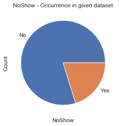

```python
print(df['Noshow'].value_counts(normalize=True))
df['Noshow'].value_counts().plot(kind = 'pie')
plt.title('NoShow - Occurrence in given dataset')
plt.xlabel('NoShow')
plt.ylabel('Count');
```

Around 20%(22,316) patient records are such where patient do not show up for schedule appointments.

We can analyse NoShow cases across categorical and numerical variables

#### Visualizing the categorical features first.

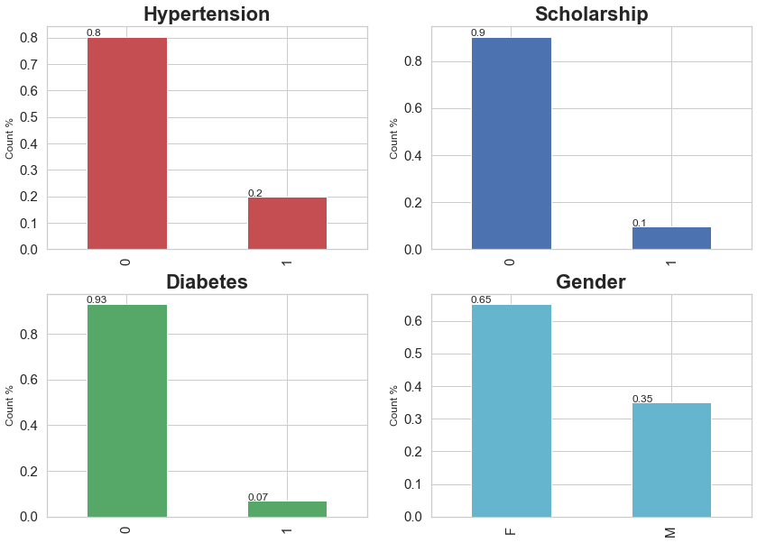

```python
#  Categorical Data
categorical_variables = ['Hypertension', 'Scholarship', 'Diabetes', 'Gender']

#  Categorical Data
i = 2  # no. of rows
j = 2  # no. of columns
k = 1  # plot counter

fig = plt.figure(figsize=(14,10))
colour = ['r', 'b', 'g', 'c']

for var in categorical_variables:
    plt.subplot(i, j, k)
    plt.title('{}'.format(var, i, j, k), fontweight="bold", fontsize = 22.0)
    ax = df[var].value_counts(normalize=True).plot.bar(fontsize = 15.0, color = colour[k-1])
    plt.ylabel('Count %')
    for p in ax.patches:
        ax.annotate(round(p.get_height(), 2), (p.get_x() * 1.005, p.get_height() * 1.005))
    k = k + 1

plt.show()
```

Observations: ~20% of patient records have Hypertension. ~10% of the patient records have scholarship. ~7% of patient recodrs have diabetes. ~35% patient instances are with male records.

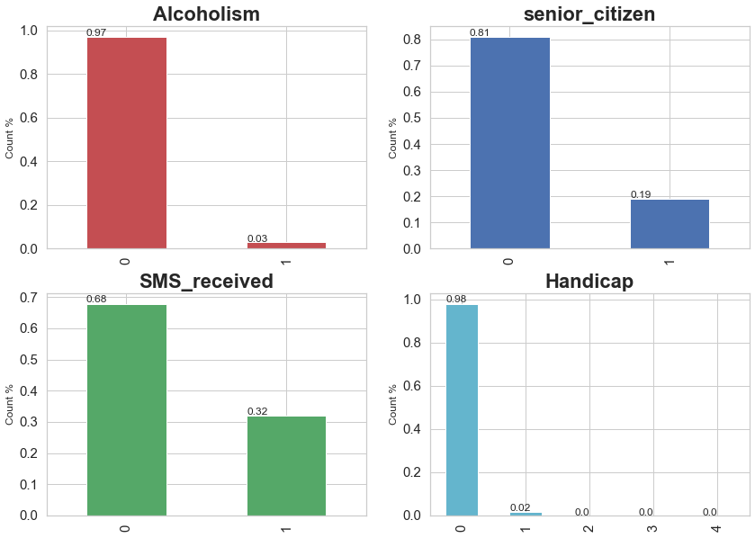

```python
#  Categorical Data
categorical_variables = ['Alcoholism', 'senior_citizen', 'SMS_received', 'Handicap']

#  Categorical Data
i = 2  # no. of rows
j = 2  # no. of columns
k = 1  # plot counter

fig = plt.figure(figsize=(14,10))
colour = ['r', 'b', 'g', 'c']

for var in categorical_variables:
    plt.subplot(i, j, k)
    plt.title('{}'.format(var, i, j, k), fontweight="bold", fontsize = 22.0)
    ax = df[var].value_counts(normalize=True).plot.bar(fontsize = 15.0, color = colour[k-1])
    plt.ylabel('Count %')
    for p in ax.patches:
        ax.annotate(round(p.get_height(), 2), (p.get_x() * 1.005, p.get_height() * 1.005))
    k = k + 1

plt.show()
```

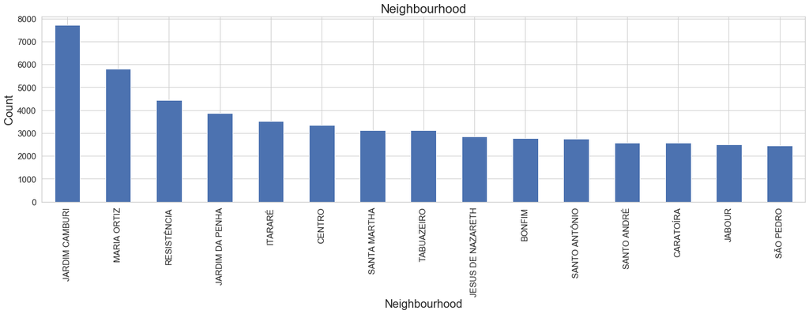

```python
df['Neighbourhood'].value_counts()[:15].plot.bar(fontsize = 15.0, figsize=(24,6))
plt.title('Neighbourhood', fontsize = 22.0)
plt.xlabel('Neighbourhood', fontsize = 20.0)
plt.ylabel('Count', fontsize = 20.0)
plt.show()
```

JARDIM CAMBURI location has majority of the patient records , followed by MARIA ORTIZ, RESISTENCIA

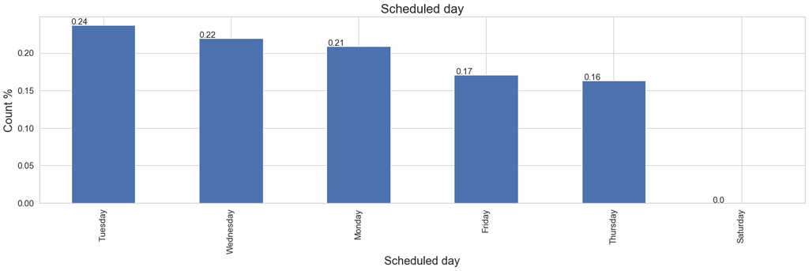

```python
ax = df['scheduled_day_name'].value_counts(normalize = True)[:15].plot.bar(fontsize = 15.0, figsize=(24,6))
for p in ax.patches:
    ax.annotate(round(p.get_height(), 2), (p.get_x() * 1.005, p.get_height() * 1.005), fontsize = 15.0)
plt.title('Scheduled day', fontsize = 22.0)
plt.xlabel('Scheduled day', fontsize = 20.0)
plt.ylabel('Count %', fontsize = 20.0)
plt.show()
```

Around 24% of schedule appointments are on Tuesday followed by 22% on wednessday

### Let's visualize the Numerical Attributes (Age, scheduled_day, appointment_day, scheduled_weekday and appointment_weekday)

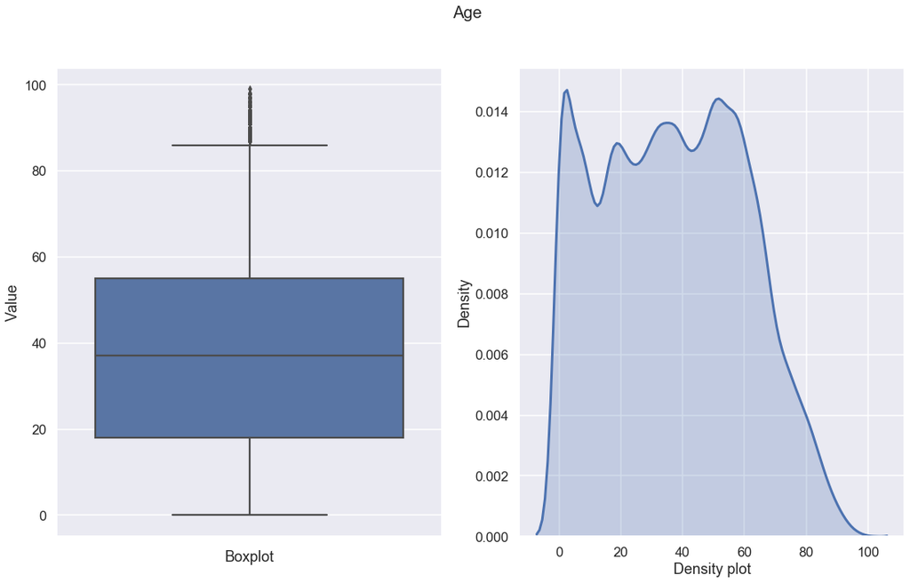

```python
kpi = 'Age'

sns.set(style="darkgrid")
sns.set_context("talk")
fig, ax =plt.subplots(1,2)

#Adding whiskers to the plots
sns.boxplot(y=kpi, data=df, palette="deep",whis=[1,99], ax=ax[0])
ax[0].set_xlabel('Boxplot')
ax[0].set_title('')
ax[0].set_ylabel('Value')

fig.suptitle(kpi, fontsize=20)
sns.distplot(df[kpi], hist = False, kde = True, kde_kws = {'shade': True, 'linewidth': 3}, ax=ax[1])
ax[1].set_xlabel('Density plot')
ax[1].set_title('')
ax[1].set_ylabel('Density')

fig.set_size_inches(18.5, 10.5)
fig.show()
```

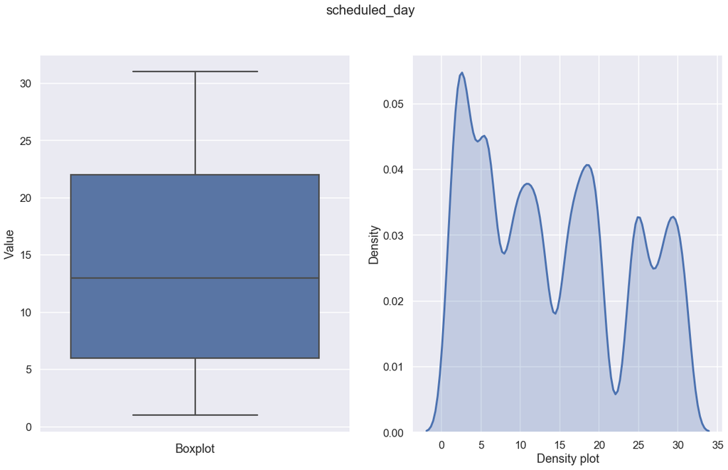

```python
kpi = 'scheduled_day'

sns.set(style="darkgrid")
sns.set_context("talk")
fig, ax =plt.subplots(1,2)

#Adding whiskers to the plots
sns.boxplot(y=kpi, data=df, palette="deep",whis=[1,99], ax=ax[0])
ax[0].set_xlabel('Boxplot')
ax[0].set_title('')
ax[0].set_ylabel('Value')

fig.suptitle(kpi, fontsize=20)
sns.distplot(df[kpi], hist = False, kde = True, kde_kws = {'shade': True, 'linewidth': 3}, ax=ax[1])
ax[1].set_xlabel('Density plot')
ax[1].set_title('')
ax[1].set_ylabel('Density')

fig.set_size_inches(18.5, 10.5)
fig.show()
```

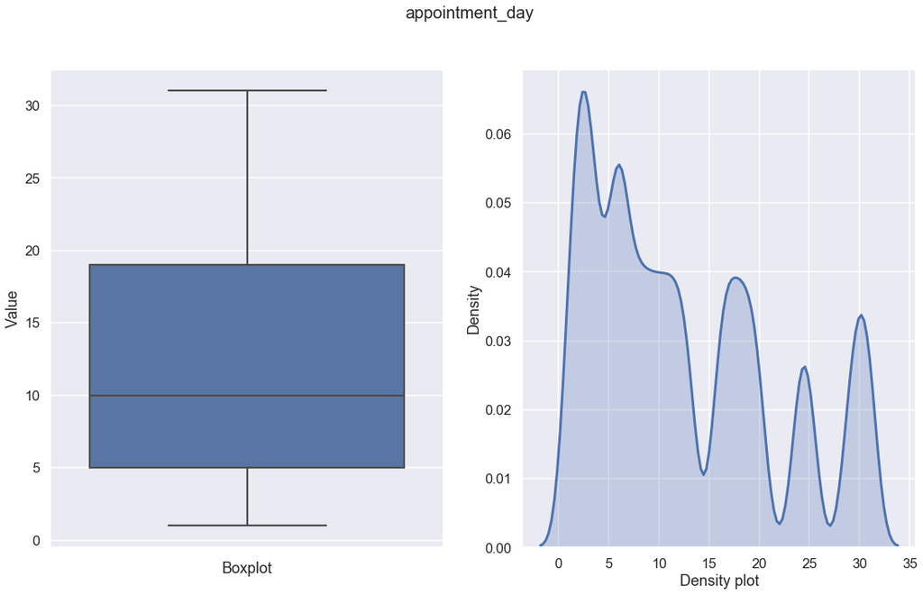

```python
kpi = 'appointment_day'

sns.set(style="darkgrid")
sns.set_context("talk")
fig, ax =plt.subplots(1,2)

#Adding whiskers to the plots
sns.boxplot(y=kpi, data=df, palette="deep",whis=[1,99], ax=ax[0])
ax[0].set_xlabel('Boxplot')
ax[0].set_title('')
ax[0].set_ylabel('Value')

fig.suptitle(kpi, fontsize=20)
sns.distplot(df[kpi], hist = False, kde = True, kde_kws = {'shade': True, 'linewidth': 3}, ax=ax[1])
ax[1].set_xlabel('Density plot')
ax[1].set_title('')
ax[1].set_ylabel('Density')

fig.set_size_inches(18.5, 10.5)
fig.show()
```

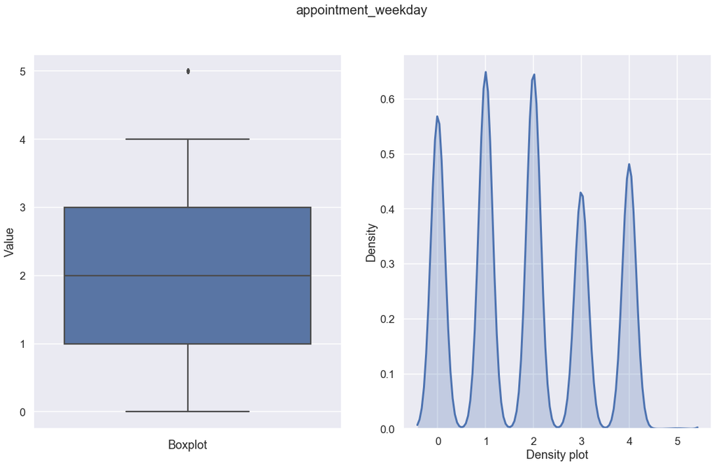

```python
kpi = 'appointment_weekday'

sns.set(style="darkgrid")
sns.set_context("talk")
fig, ax =plt.subplots(1,2)

#Adding whiskers to the plots
sns.boxplot(y=kpi, data=df, palette="deep",whis=[1,99], ax=ax[0])
ax[0].set_xlabel('Boxplot')
ax[0].set_title('')
ax[0].set_ylabel('Value')

fig.suptitle(kpi, fontsize=20)
sns.distplot(df[kpi], hist = False, kde = True, kde_kws = {'shade': True, 'linewidth': 3}, ax=ax[1])
ax[1].set_xlabel('Density plot')
ax[1].set_title('')
ax[1].set_ylabel('Density')

fig.set_size_inches(18.5, 10.5)
fig.show()
```

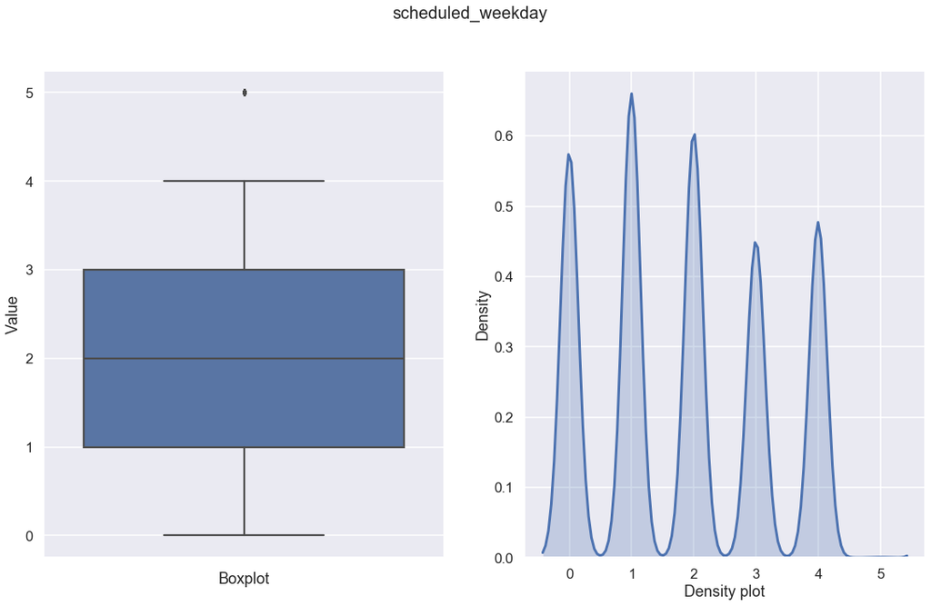

```python
kpi = 'scheduled_weekday'

sns.set(style="darkgrid")
sns.set_context("talk")
fig, ax =plt.subplots(1,2)

#Adding whiskers to the plots
sns.boxplot(y=kpi, data=df, palette="deep",whis=[1,99], ax=ax[0])
ax[0].set_xlabel('Boxplot')
ax[0].set_title('')
ax[0].set_ylabel('Value')

fig.suptitle(kpi, fontsize=20)
sns.distplot(df[kpi], hist = False, kde = True, kde_kws = {'shade': True, 'linewidth': 3}, ax=ax[1])
ax[1].set_xlabel('Density plot')
ax[1].set_title('')
ax[1].set_ylabel('Density')

fig.set_size_inches(18.5, 10.5)
fig.show()
```

### Bi-variate Analysis

#### Target Variable vs Indepedent Categorical Variable

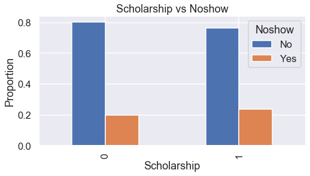

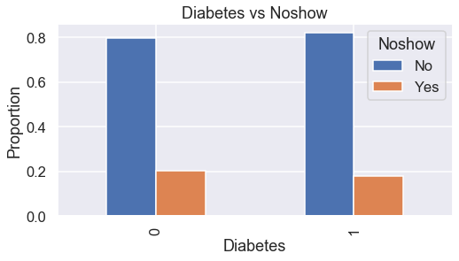

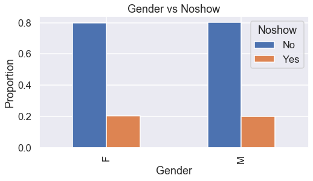

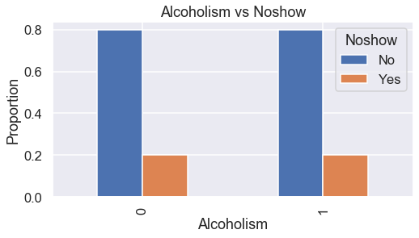

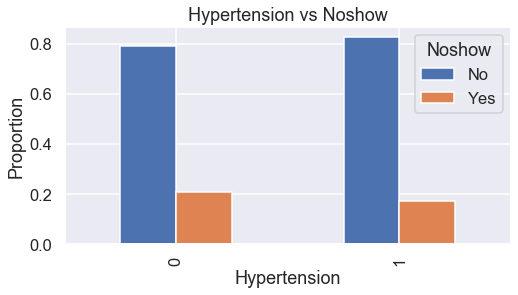

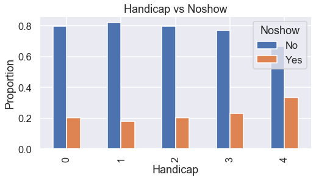

```python
category_list = [ 'Scholarship', 'Diabetes', 'Gender', 'Alcoholism', 'Hypertension', 'Handicap']
for col in category_list:
    df1 = pd.crosstab(df[col],df['Noshow'])
    df1.div(df1.sum(1).astype(float), axis=0).plot(kind="bar", figsize=(8,4));
    plt.ylabel('Proportion')
    plt.title(col + ' vs Noshow');
```

Onservations: Patients who have scholarship have slightly more "NoShow" status Patients who have Diabetes have slightly less "NoShow" status Patients who have Hypertension have slightly less "NoShow" status Not much of difference in "NoShow" status for Gender and Alcholism data cuts Ptaients with Handicap category 4 have more "NoShow" status

#### Bi-variate Analysis on Numeric variables vs Target variable

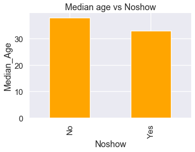

```python
df.groupby('Noshow')['Age'].median().plot(kind = 'bar', color = 'Orange')
plt.ylabel('Median_Age');
plt.title('Median age vs Noshow');
```

The median age group of records with "Noshow" have lesser age

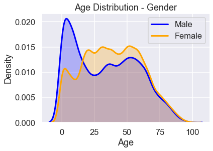

```python
lst1 = list(df[df['Gender'] == 'M']['Age'])
lst2 = list(df[df['Gender'] == 'F']['Age'])
sns.distplot(lst1, label='Male', color="Blue", hist = False, kde = True, kde_kws = {'shade': True, 'linewidth': 3})
sns.distplot(lst2, label='Female', color="Orange", hist = False, kde = True, kde_kws = {'shade': True, 'linewidth': 3})
plt.title('Age Distribution - Gender')
plt.xlabel('Age')
plt.ylabel('Density')
plt.show()
```

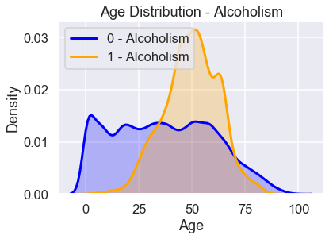

```python
lst1 = list(df[df['Alcoholism'] == 0]['Age'])
lst2 = list(df[df['Alcoholism'] == 1]['Age'])
sns.distplot(lst1, label='0 - Alcoholism', color="Blue", hist = False, kde = True, kde_kws = {'shade': True, 'linewidth': 3})
sns.distplot(lst2, label='1 - Alcoholism', color="Orange", hist = False, kde = True, kde_kws = {'shade': True, 'linewidth': 3})
plt.title('Age Distribution - Alcoholism')
plt.xlabel('Age')
plt.ylabel('Density')
plt.show()
```

### We will try to answer following questions with the help of the data

### 1. Does Gender has any impact on patient to be with status Show / No-Show?

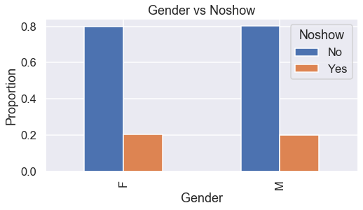

```python
col = 'Gender'
df1 = pd.crosstab(df[col],df['Noshow'])
df1.div(df1.sum(1).astype(float), axis=0).plot(kind="bar", figsize=(8,4));
plt.title('Gender vs Noshow')
plt.xlabel('Gender')
plt.ylabel('Proportion')
plt.show()
```

Gender does not have much inluence in having the status with Show/No Show

### 2. Does Age has any impact on patient to be with status Show / No-Show?

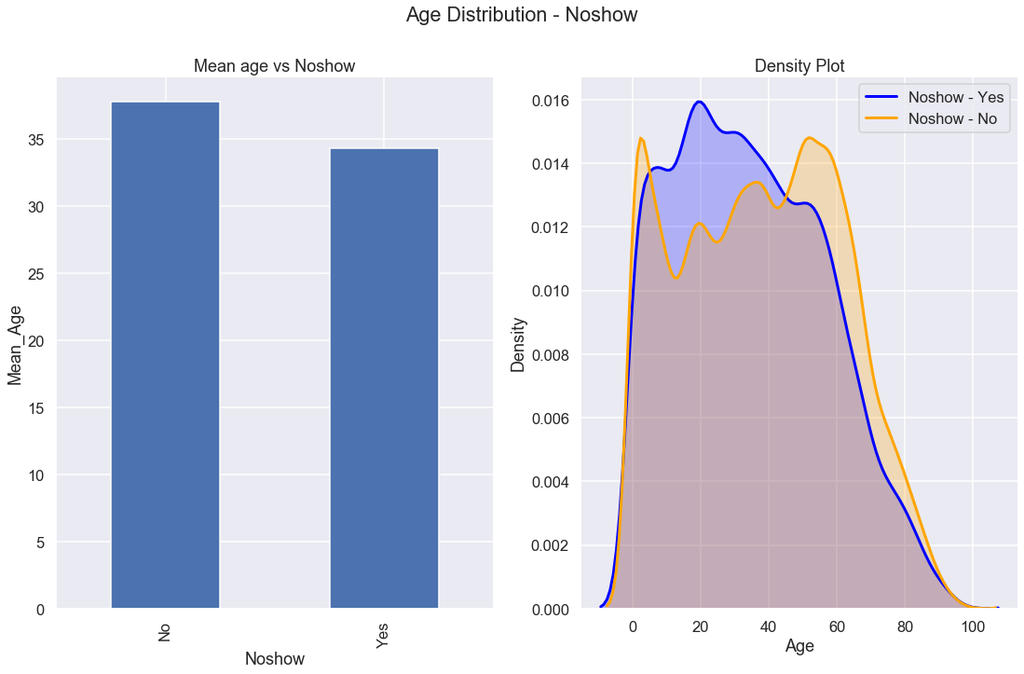

```python
sns.set(style="darkgrid")
sns.set_context("talk")
fig, ax =plt.subplots(1,2)

#Adding whiskers to the plots
df.groupby('Noshow')['Age'].mean().plot.bar(ax = ax[0])
ax[0].set_xlabel('Noshow')
ax[0].set_title('Mean age vs Noshow')
ax[0].set_ylabel('Mean_Age')

lst1 = list(df[df['Noshow'] == 'Yes']['Age'])
lst2 = list(df[df['Noshow'] == 'No']['Age'])
sns.distplot(lst1, label='Noshow - Yes', color="Blue", hist = False, kde = True, kde_kws = {'shade': True, 'linewidth': 3}, ax=ax[1])
sns.distplot(lst2, label='Noshow - No', color="Orange", hist = False, kde = True, kde_kws = {'shade': True, 'linewidth': 3}, ax=ax[1])
ax[1].set_xlabel('Age')
ax[1].set_title('Density Plot')
ax[1].set_ylabel('Density')


fig.suptitle('Age Distribution - Noshow')
fig.set_size_inches(18.5, 10.5)
fig.show()
```

The mean age group of patients with "No Show = Yes" is less than patients with "No Show = No"

### 3. Is there any Age difference along with Gender difference with the status of Show / NoShow?

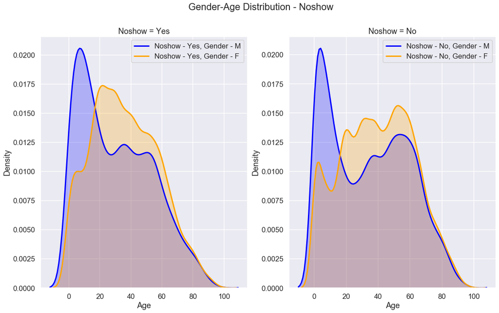

```python
sns.set(style="darkgrid")
sns.set_context("talk")
fig, ax =plt.subplots(1,2)

#Adding whiskers to the plots
lst1 = list(df[(df['Noshow'] == 'Yes') & (df['Gender'] == 'M')]['Age'])
lst2 = list(df[(df['Noshow'] == 'Yes') & (df['Gender'] == 'F')]['Age'])
sns.distplot(lst1, label='Noshow - Yes, Gender - M', color="Blue", hist = False, kde = True, kde_kws = {'shade': True, 'linewidth': 3}, ax=ax[0])
sns.distplot(lst2, label='Noshow - Yes, Gender - F', color="Orange", hist = False, kde = True, kde_kws = {'shade': True, 'linewidth': 3}, ax=ax[0])
ax[0].set_xlabel('Age')
ax[0].set_title('Noshow = Yes')
ax[0].set_ylabel('Density')

lst1 = list(df[(df['Noshow'] == 'No') & (df['Gender'] == 'M')]['Age'])
lst2 = list(df[(df['Noshow'] == 'No') & (df['Gender'] == 'F')]['Age'])
sns.distplot(lst1, label='Noshow - No, Gender - M', color="Blue", hist = False, kde = True, kde_kws = {'shade': True, 'linewidth': 3}, ax=ax[1])
sns.distplot(lst2, label='Noshow - No, Gender - F', color="Orange", hist = False, kde = True, kde_kws = {'shade': True, 'linewidth': 3}, ax=ax[1])
ax[1].set_xlabel('Age')
ax[1].set_title('Noshow = No')
ax[1].set_ylabel('Density')


fig.suptitle('Gender-Age Distribution - Noshow')
fig.set_size_inches(18.5, 10.5)
fig.show()
```

## Limitations

The data has information only for April, May and June. If atleast full year data would have provided, we could identify some trends MoM.

If we had some way of reminding patients regarding appointments and would have captured that data, we could identify how many reminders are needed for patient to show up

## Conclusions

Gender does not have much inluence in having the status with Show/No Show

The mean age group of patients with "No Show = Yes" is less than patients with "No Show = No"

## References

1. Book - Learning Pandas
2. Websites - a. www.stackoverflow.com, b. www.geeksforgeeks.com, c. www.towardsdatascience.com